# String Distance Comparisons

Jolene Lim

# 1. Setup

Load required libraries

```r
library(kableExtra)
library(tidyverse)
library(fuzzyjoin)
```

Load datasets

```r
# load datasets
sample <- read_csv(here::here("Data/us1910m_usa_sample100k.csv"))
edict <- read_csv(here::here("Data/combined_edict_mn.csv"))

# clean column names
names(sample) <- c("hnyc_id", "record", "township", "county", "ED", "person_id",
                   "dwelling_seq", "dwelling_ser", "dwelling_ser2", "hh_seq", "hh_seq_8",
                   "hh_ser2", "hh_ser_bef_split", "indiv_seq", "split",
                   "line_no", "line_no2", "microfilm",
                   "n_fam", "n_person_bef_split", "house_num", "street_add")

# add ED no
edict <- edict %>%
  mutate(ED = str_pad(ED, 4, "left", pad = "0")) # ensure numbers are all 4 digit
```

Extract only unique combinations of EDs and addresses

```r
unique_addresses <- sample %>%
  select(ED, street_add) %>%
  filter(!is.na(street_add)) %>%
  distinct(ED, street_add)
```

# 2. Cleaning Addresses

Importing functions created by Kyi, `rem_dup_word()` and `str_clean()`. Note: `str_clean()` is modified such that the output is a cleaned `x` rather than `x$cleaned`. This allows `x` to be a vector rather than strictly a dataframe.

```r
# import functions
rem_dup_word <- function(x){
x <- tolower(x)
paste(unique(trimws(unlist(strsplit(x,split=" ",fixed=F,perl=T)))),collapse =
" ")
}

str_clean<-function(x){
  x <- gsub("\\<SRT\\>$|\\<SR\\>$\\<SRT\\>$|\\<STR\\>$|\\<SST\\>$|\\<SEET\\>$|\\<TREET\\>$|\\<SHEER\\>$|\\<SHEE\\>$|\\<STREE\\>$|\\<SREET\\>$|\\<REET\\>$|\\<STEE\\>$|\\<ST\\>$","STREET",x)
  x <-gsub("\\<N\\>","NORTH",x)
  x<-gsub("\\<S\\>","SOUTH",x)
  x<-gsub("\\<E\\>","EAST",x)
  x<-gsub("\\<W\\>","WEST",x)
  x<-gsub("\\<DR\\>|\\<DV\\>|\\<DE\\>$|\\<DRV\\>|\\<DRI\\>|\\<DRIV\\>|\\<DRIE\\>","DRIVE",x)
  x<-gsub("\\<CIR\\>|\\<CRL\\>|\\<CIRC\\>|\\<CR\\>|\\<CL\\>|\\<CIRCL\\>|\\<CICLE\\>","CIRCLE",x)
  x<-gsub("\\<AVE\\>|\\<AV\\>|\\<AVN\\>|\\<AVEN\\>|\\<AVENU\\>","AVENUE",x)
  x<-gsub("\\<CT\\>|\\<CRT\\>|\\<CTR\\>|\\<COUR\\>|\\<COT\\>|\\<CORT\\>","COURT",x)
  x<-gsub("\\<BLVD\\>|\\<BVLD\\>|\\<BV\\>|\\<BLD\\>|\\<BD\\>|\\<BL\\>|\\<BLV\\>","BOULEVARD",x)
  x<-gsub("\\<RD\\>|\\<RAD\\>|\\<ROD\\>","ROAD",x)
  x<-gsub("\\<ALY\\>|\\<AL\\>|\\<ALLY\\>|\\<ALEY\\>|\\<ALLE\\>|\\<AY\\>","ALLEY",x)
  x<-gsub("\\<PL\\>|\\<PLC\\>|\\<PLE\\>|\\<PC\\>|\\<PLAC\\>|\\<PLCE\\>|\\<PCE\\>","PLACE",x)
  x<-gsub("\\<PK\\>|\\<PRK\\>|\\<PRAK\\>|\\<PAK\\>","PARK",x)
  x<-gsub("\\<PKWY\\>|\\<PARKW\\>|\\<PWY\\>|\\<PKW\\>|\\<PRKWY\\>|\\<PKWY\\>|\\<PKW\\>","PARKWAY",x)
  x<-gsub("\\<APPR\\>|\\<APR\\>|\\<APPROA\\>|\\<APRCH\\>|\\<APPRCH\\>","APPROACH",x)
  x<-gsub("\\<TER\\>|\\<TERR\\>|\\<TRC\\>|\\<TRCE\\>|\\<TR\\>","TERRACE",x)
  x<-gsub("\\<PLZ\\>|\\<PLAZ\\>|\\<PZ\\>|\\<PLZA\\>","PLAZA",x)
  x<-gsub("\\<LN\\>|\\<LNE\\>|\\<LAN\\>","LANE",x)
  x<-gsub("\\<BRG\\>|\\<BRGD\\>|\\<BGE\\>","BRIDGE",x)
  x<-gsub("\\<HL\\>|\\<HLL\\>|\\<HIL\\>","HILL",x)
  x<-gsub("\\<HTS\\>|\\<HT\\>|\\<HEIGHT\\>|\\<HEGHTS\\>|\\<HHT\\>|\\<HEIGT\\>","HEIGHTS",x)
  x<-gsub(".*\\((.*)\\).*", "\\1", x)
  x<-str_remove(x,"STREET")
  x<-gsub("\\d+\\ - *\\d*|\\d+\\ TO *\\d*|\\d+\\-\\d*","",x) #remove addresses

  ## dealing with numbered streets
x<-gsub("(\\d)(ST|ND|RD|TH)\\b", "\\1", x)
x<-str_remove(x, "(?<=[0-9])(ST|ND|RD|TH)")
x<-gsub("\\<ONE HUNDRED\\>|\\<ONEHUNDRED\\>|\\<HUNDRED\\>|\\<HUDRED\\>|\\<HUNDED\\>","1",x)
x<-gsub("\\<TWO HUNDRED\\>|\\<TWOHUNDRED\\>","2",x)
x<-gsub("-"," ",x)
x<-gsub("\\<AND\\>"," ",x)
x<-gsub("&"," ",x)
x<-gsub("\\<1ST\\>|\\b1\\b","FIRST",x)
x<-gsub("\\<2ND\\>|\\b2\\b","SECOND",x)
x<-gsub("\\<3RD\\>|\\b3\\b","THIRD",x)
x<-gsub("\\<4TH\\>|\\b4\\b","FOURTH",x)
x<-gsub("\\<5TH\\>|\\b5\\b","FIFTH",x)
x<-gsub("\\<6TH\\>|\\b6\\b","SIXTH",x)
x<-gsub("\\<7TH\\>|\\b7\\b","SEVENTH",x)
x<-gsub("\\<8TH\\>|\\b8\\b","EIGHTH",x)
x<-gsub("\\<9TH\\>|\\b9\\b","NINTH",x)
x<-gsub("\\<10TH\\>|\\b10\\b","TENTH",x)
x<-gsub("\\<11TH\\>|\\b11\\b","ELEVENTH",x)
x<-gsub("\\<12TH\\>|\\b12\\b","TWELFTH",x)
x<-gsub("\\<13TH\\>|\\b13\\b","THIRTEENTH",x)
x<-gsub("\\<14TH\\>|\\b14\\b","FORTEENTH",x)
x<-gsub("\\<15TH\\>|\\b15\\b","FIFTEENTH",x)
x<-gsub("\\<16TH\\>|\\b16\\b","SIXTEENTH",x)
x<-gsub("\\<17TH\\>|\\b17\\b","SEVENTEENTH",x)
x<-gsub("\\<18TH\\>|\\b18\\b","EIGHTEENTH",x)
x<-gsub("\\<19TH\\>|\\b19\\b","NINETEENTH",x)
x<-gsub("\\<TWENTY\\>|\\<TWENTI\\>|\\<TENTI\\>","2",x)
x<-gsub("\\<THIRTY\\>|\\<THIRTHY\\>|\\<THIRTEY\\>|\\<TIRTY\\>|\\<TRITHY\\>","3",x)
x<-gsub("\\<FORTY\\>|\\<FOURTY\\>|\\<FOURTHY\\>|\\<FRTY\\>","4",x)
x<-gsub("\\<FIFTY\\>|\\<FIFTEY\\>|\\<FIFT\\>|\\<FITY\\>|\\<FIFTHY\\>","5",x)
x<-gsub("\\<SIXTY\\>|\\<SXTY\\>|\\<SIXY\\>|\\<SXTY\\>|\\<SIXTHY\\>|\\<SIXTEY\\>","6",x)
x<-gsub("\\<SEVENT\\>|\\<SEVENTY\\>|\\<SEVENTEY\\>|\\<SVENTY\\>|\\<SEVENTI\\>","7",x)
x<-gsub("\\<EIGHTY\\>|\\<EIGHTEY\\>|\\<EIGHTE\\>","8",x)
x<-gsub("\\<UNITY\\>|\\<NINTH\\>|\\<NINETY\\>|\\<NINETEY\\>|\\<NINETIETH\\>|\\<NINTY\\>","9",x)
x<-gsub("\\<FRIST\\>|\\<FIST\\>|\\<FRST\\>|\\<FIRST\\>|\\<ONE\\>","1",x)
x<-gsub("\\<SECOND\\>|\\<SECORD\\>|\\<SCOND\\>|\\<SECOND\\>|\\<TWO\\>","2",x)
x<-gsub("\\<THRID\\>|\\<THIRD\\>|\\<TIRD\\>|\\<TRIHD\\>|\\<THREE\\>","3",x)
x<-gsub("\\<FORTH\\>|\\<FOURTH\\>|\\<FROTH\\>|\\<FROUTH\\>|\\<FOUR\\>","4",x)
x<-gsub("\\<FIFETH\\>|\\<FIFTH\\>|\\<FIFFTH\\>|\\<FIFTHE\\>|\\<FIVE\\>","5",x)
x<-gsub("\\<SIXTH\\>|\\<SXTH\\>|\\<SITH\\>|\\<SIHXT\\>|\\<SIX\\>","6",x)
x<-gsub("\\<SEVENTH\\>|\\<SVEN\\>|\\<SVENTH\\>|\\<SEVENH\\>|\\<SEVENT\\>|\\<SEVEN\\>","7",x)
x<-gsub("\\<EIGHTH\\>|\\<EIGHTEH\\>|\\<EITH\\>|\\<EIGHT\\>","8",x)
x<-gsub("\\<NINETH\\>|\\<NINTH\\>|\\<NINT\\>|\\<NINETH\\>|\\<NINE\\>|\\<NIN\\>","9",x)
x<-gsub("\\<TWENTIETH\\>|\\<TWENTIEFTH\\>","20",x) #NEW
x<-gsub("\\<THIRTIETH\\>|\\<THIRTIEFTH\\>","30",x)
x<-gsub("\\<FORTIETH\\>|\\<FOURTIETH\\>","40",x)
x<-gsub("\\<FIFTIETH\\>","50",x)
x<-gsub("\\<SIXTIETH\\>","60",x)
x<-gsub("\\<SEVENTIETH\\>","70",x)
x<-gsub("\\<EIGHTIETH\\>","80",x)
x<-gsub("\\<NINETIETH\\>|\\<NINTIETH\\>","90",x)
x<-gsub("(?<=\\d) (?=\\d)","",x,perl = T) #new close gaps between all numbers
## place names
  ##x<-gsub("\\bSTR\\b","", x)
  x<-gsub("^\\bST\\b","SAINT", x)
  x<-gsub("\\bHOUSE\\b","", x)
  x<-gsub("\\bHOSTEL\\b","", x)
  x<-gsub("\\bHOTEL\\b","", x)
  x<-gsub("\\bLODGE\\b","", x)
  x<-gsub("\\bLODGING\\b","", x)
  x<-trimws(x, "both")
  x<-gsub("\\<N\\>","NORTH",x)
  ##x<-gsub("\\<ST\\>","",x)
  ##x<-gsub("\\<STREET\\>","",x)
}
```

Applying the functions onto `unique_addresses`

```r
# preallocate memory for cleaned column
cleaned <- rep("", nrow(unique_addresses))

# apply rem_dup_word() and str_clean()
for (i in 1:nrow(unique_addresses)) {
cleaned[i] <- toupper(rem_dup_word(unique_addresses[i, 2]))
cleaned[i] <- str_clean(cleaned[i])
}
```

# 3. Matching Addresses with EDict

The goal here is to create a “dictionary of matches”, `match_dict`, which contains the variables:  
* ED  
* raw: raw address from sample  
* match_{method}: cleaned address that exists in the street dictionary (`edict`)  
* dscore_{method}: dscore between match and cleaned address  
where {method} is one of the string match methods explained below.

The purpose of `match_dict` is so that when matching between a raw address and cleaned Edict address needs to be done for the entire sample, one can just look up the `raw` address in `match_dict` and take the `matched` address as the cleaned, matching address.

### Note: String Match Algorithms

To do so, it is first necessary to match records from the `edict` to raw and decide which match (based on different string distance algorithms) is the most accurate. A intermediate dataframe, `add_matches`, will be created for this purpose.

All string algorithms provided by `stringdist_join()` function will be tested, with the exception of: * Hamming: It requires both strings to be of equal distance, which is unlikely the case for accurate matches in our context.  
* LCS (Longest Common Substring): It calculates the minimum number of symbols that have to be removed in both strings until resulting substrings are identical. In our case transposition is the likelier error compared to additional characters introduced by typos, hence this is not very useful.  
* Soundex: This is a binary match system which may be too strict for our purposes. * Levenshtein distance (lv) and Optimal String Alignment (OSA): these are similar to the Damerau-Levenshtein distance (dl) but stricter, hence only dl is chosen.

```r
# create add_matches, which combines `unique_addresses` with the `cleaned` column
add_matches <- tibble(ED = unique_addresses$ED,
                      raw = unique_addresses$street_add,
                      clean = cleaned)


# create str_algo, which has all the methods we will use
str_algo <- c("dl", "qgram", "cosine", "jaccard", "jw")

# create empty lists which will store outputs
algo_list <- list()
ed_list <- list()
```

```r
for (i in unique(add_matches$ED)) {
  # create subset of edict and add_matches for a particular ED
  # TO ACCEPT BK: ED_dict <- filter(edict, ED == i & MNBK == "BK") %>%
  ED_dict <- filter(edict, ED == i) %>%
    select(- "ED") %>%
    unlist()
  ED_dict <- data.frame(clean = ED_dict, stringsAsFactors = FALSE) %>%
    filter(!is.na(clean))
  ED_add <- filter(add_matches, ED == i)

  for (j in str_algo) {
    # stringdist_join, extract best match for each method
    result <- stringdist_left_join(ED_add, ED_dict, by = "clean",
                                   max_dist = 5, method = j, distance_col = "dscore") %>%
    select(ED, raw, clean.x, clean.y, dscore) %>%
    group_by(raw) %>%
    arrange(dscore) %>%
    slice(1)

    # at this point, result = dataframe of addresses in ED (i), merged with method (j)
    # append result to algo_list, each element in algo_list is a dataframe
    algo_list[[j]] <- result

    # "column bind" all elements in algo_list to form a df called ed_df
    # ed_df now contains all addresses in ED(i) with matches using all methods
    ed_df <- algo_list %>%
      reduce(left_join, by = c("ED", "raw", "clean.x"))
  }
  # append each ed_df to ed_list
  ed_list[[i]] <- ed_df
}

# bind all dfs by row
match_dict <- bind_rows(ed_list) %>%
    select(ED = "ED", raw = "raw", clean = "clean.x",
           match_dl = "clean.y.x", dscore_dl = "dscore.x",
           match_qgram = "clean.y.y", dscore_qgram = "dscore.y",
           match_cos = "clean.y.x.x", dscore_cos = "dscore.x.x",
           match_jac = "clean.y.y.y", dscore_jac = "dscore.y.y",
           match_jw = "clean.y", dscore_jw = "dscore")

head(match_dict) %>%
  kable() %>% kable_styling() %>% scroll_box(width = "100%")
```

| ED | raw | clean | match_dl | dscore_dl | match_qgram | dscore_qgram | match_cos | dscore_cos | match_jac | dscore_jac | match_jw | dscore_jw |
| --- | --- | --- | --- | --- | --- | --- | --- | --- | --- | --- | --- | --- |
| 0020 | CARL STREET | CARL | PEARL | 2 | PEARL | 3 | PEARL | 0.3291796 | PEARL | 0.5000000 | PEARL | 0.2166667 |
| 0020 | HARDISON STREET | HARDISON | MADISON | 2 | MADISON | 3 | MADISON | 0.1982163 | MADISON | 0.3333333 | MADISON | 0.1309524 |
| 0020 | MADISON SST | MADISON | MADISON | 0 | MADISON | 0 | MADISON | 0.0000000 | MADISON | 0.0000000 | MADISON | 0.0000000 |
| 0020 | PARK ROSE | PARK ROSE | PARK ROW | 2 | PARK ROW | 3 | PARK ROW | 0.1418837 | PARK ROW | 0.3333333 | PARK ROW | 0.1157407 |
| 0020 | PARK ROW | PARK ROW | PARK ROW | 0 | PARK ROW | 0 | PARK ROW | 0.0000000 | PARK ROW | 0.0000000 | PARK ROW | 0.0000000 |
| 0020 | PEARL STREET | PEARL | PEARL | 0 | PEARL | 0 | PEARL | 0.0000000 | PEARL | 0.0000000 | PEARL | 0.0000000 |

# 4. EDA of Results

## How consistent are the matches?

Ideally, all 5 algorithm matches will perfectly match the clean string. This table explores the number of records by the number of perfect matches with (which ranges from 0-5), e.g. 0 would mean that none of the algorithms produced a perfect match with the cleaned string.

```r
n_match <- match_dict %>%
  mutate(yes_dl = clean == match_dl,
         yes_qgram = clean == match_qgram,
         yes_cos = clean == match_cos,
         yes_jac = clean == match_jac,
         yes_jw = clean == match_jw) %>%
  replace(is.na(.), 0) %>% # so that NA matches are 0
  mutate(sum_match = yes_dl + yes_qgram + yes_cos + yes_jac + yes_jw)

table(n_match$sum_match) %>%
  as.data.frame() %>% mutate(perc = round(Freq / nrow(add_matches) * 100, 1)) %>%
  kable(col.names = c("No. of Perfect Matches", "No. of Records", "%")) %>%
  kable_styling(full_width = FALSE)
```

| No. of Perfect Matches | No. of Records | % |
| --- | --- | --- |
| 0 | 359 | 58.8 |
| 2 | 10 | 1.6 |
| 5 | 242 | 39.6 |

242 (39.6%) records have a perfect match.

```r
n_match_within_algo <- match_dict %>%
  distinct(ED, raw, .keep_all = TRUE) %>%
  gather(key = "method", value = "match",
         c("match_dl", "match_qgram", "match_cos", "match_jac", "match_jw")) %>%
  group_by(ED, raw) %>%
  summarise(n_diff_match = n_distinct(match))

table(n_match_within_algo$n_diff_match) %>%
  as.data.frame() %>% mutate(perc = round(Freq / nrow(add_matches) * 100, 1)) %>%
  kable(col.names = c("No. of Unique Matches Given by Algorithms", "No. of Records", "%")) %>%
  kable_styling(full_width = FALSE)
```

| No. of Unique Matches Given by Algorithms | No. of Records | % |
| --- | --- | --- |
| 1 | 394 | 64.5 |
| 2 | 165 | 27.0 |
| 3 | 44 | 7.2 |
| 4 | 8 | 1.3 |

We know that 242 records have perfect matches between all results from the string algorithms and the clean string. Additionally, 394 - 242 = 152 (24.9%) records have all string algorithms giving the same result–suggesting that this is a problem with the cleaning rather than matching. To verify this, the records that are not a perfect match, but have all the same results are shown below:

```r
match_dict %>%
  replace(is.na(.), 0) %>%
  filter(clean != match_dl &
         match_dl == match_qgram &
         match_dl == match_cos &
         match_dl == match_jac &
         match_dl == match_jw) %>%
  kable %>% kable_styling() %>% scroll_box(width = "100%", height = "500px")
```

| ED | raw | clean | match_dl | dscore_dl | match_qgram | dscore_qgram | match_cos | dscore_cos | match_jac | dscore_jac | match_jw | dscore_jw |
| --- | --- | --- | --- | --- | --- | --- | --- | --- | --- | --- | --- | --- |
| 0020 | CARL STREET | CARL | PEARL | 2 | PEARL | 3 | PEARL | 0.3291796 | PEARL | 0.5000000 | PEARL | 0.2166667 |
| 0020 | HARDISON STREET | HARDISON | MADISON | 2 | MADISON | 3 | MADISON | 0.1982163 | MADISON | 0.3333333 | MADISON | 0.1309524 |
| 0020 | PARK ROSE | PARK ROSE | PARK ROW | 2 | PARK ROW | 3 | PARK ROW | 0.1418837 | PARK ROW | 0.3333333 | PARK ROW | 0.1157407 |
| 0020 | ROOSEVLT STREET | ROOSEVLT | ROOSEVELT | 1 | ROOSEVELT | 1 | ROOSEVELT | 0.0352362 | ROOSEVELT | 0.0000000 | ROOSEVELT | 0.0370370 |
| 0021 | NAMES STREET | NAMES | JAMES | 1 | JAMES | 2 | JAMES | 0.2000000 | JAMES | 0.3333333 | JAMES | 0.1333333 |
| 0021 | SAMES STREET | SAMES | JAMES | 1 | JAMES | 2 | JAMES | 0.1548457 | JAMES | 0.2000000 | JAMES | 0.1333333 |
| 0022 | NEW BREWERY | NEW BREWERY | NEW BOWERY | 2 | NEW BOWERY | 3 | NEW BOWERY | 0.0668611 | NEW BOWERY | 0.1250000 | NEW BOWERY | 0.1309764 |
| 0022 | SAMES STREET | SAMES | JAMES | 1 | JAMES | 2 | JAMES | 0.1548457 | JAMES | 0.2000000 | JAMES | 0.1333333 |
| 0023 | KATHERINE SREET | KATHERINE | CATHERINE | 1 | CATHERINE | 2 | CATHERINE | 0.0909091 | CATHERINE | 0.2222222 | CATHERINE | 0.0740741 |
| 0023 | KATHERINE STREET | KATHERINE | CATHERINE | 1 | CATHERINE | 2 | CATHERINE | 0.0909091 | CATHERINE | 0.2222222 | CATHERINE | 0.0740741 |
| 0023 | LIVES STREET | LIVES | OLIVER | 2 | OLIVER | 3 | OLIVER | 0.2697033 | OLIVER | 0.4285714 | OLIVER | 0.1777778 |
| 0023 | MADRIN ST | MADRIN | MADISON | 3 | MADISON | 3 | MADISON | 0.2284833 | MADISON | 0.3750000 | MADISON | 0.1507937 |
| 0023 | OLIVES STREET | OLIVES | OLIVER | 1 | OLIVER | 2 | OLIVER | 0.1666667 | OLIVER | 0.2857143 | OLIVER | 0.1111111 |
| 0180 | CATHARINE STREET | CATHARINE | CATHERINE | 1 | CATHERINE | 2 | CATHERINE | 0.0909091 | CATHERINE | 0.0000000 | CATHERINE | 0.0740741 |
| 0024 | JAUNE SHEER | JAUNE | JAMES | 3 | JAMES | 4 | JAMES | 0.4000000 | JAMES | 0.5714286 | JAMES | 0.2666667 |
| 0024 | JAUNE STREET | JAUNE | JAMES | 3 | JAMES | 4 | JAMES | 0.4000000 | JAMES | 0.5714286 | JAMES | 0.2666667 |
| 0024 | MADDISON ST | MADDISON | MADISON | 1 | MADISON | 1 | MADISON | 0.0438171 | MADISON | 0.0000000 | MADISON | 0.0416667 |
| 0024 | OLWER | OLWER | OLIVER | 2 | OLIVER | 3 | OLIVER | 0.2697033 | OLIVER | 0.4285714 | OLIVER | 0.1777778 |
| 0024 | OLWER ST | OLWER | OLIVER | 2 | OLIVER | 3 | OLIVER | 0.2697033 | OLIVER | 0.4285714 | OLIVER | 0.1777778 |
| 0024 | OLWER STREET | OLWER | OLIVER | 2 | OLIVER | 3 | OLIVER | 0.2697033 | OLIVER | 0.4285714 | OLIVER | 0.1777778 |
| 0025 | ROSSEVELT STREET | ROSSEVELT | ROOSEVELT | 1 | ROOSEVELT | 2 | ROOSEVELT | 0.0769231 | ROOSEVELT | 0.0000000 | ROOSEVELT | 0.0740741 |
| 0026 | CATHARINE ST | CATHARINE | CATHERINE | 1 | CATHERINE | 2 | CATHERINE | 0.0909091 | CATHERINE | 0.0000000 | CATHERINE | 0.0740741 |
| 0026 | CATHARINE STREET | CATHARINE | CATHERINE | 1 | CATHERINE | 2 | CATHERINE | 0.0909091 | CATHERINE | 0.0000000 | CATHERINE | 0.0740741 |
| 0026 | DAK STREET | DAK | OAK | 1 | OAK | 2 | OAK | 0.3333333 | OAK | 0.5000000 | OAK | 0.2222222 |
| 0026 | OLWEN STREET | OLWEN | OLIVER | 3 | OLIVER | 5 | OLIVER | 0.4522774 | OLIVER | 0.6250000 | OLIVER | 0.3000000 |
| 0029 | 8 JAMES SLIP | 8 JAMES SLIP | JAMES SLIP | 2 | JAMES SLIP | 2 | JAMES SLIP | 0.0618058 | JAMES SLIP | 0.1000000 | JAMES SLIP | 0.1555556 |
| 0029 | BATTER INC SLIP | BATTER INC SLIP | CATHERINE SLIP | 4 | CATHERINE SLIP | 5 | CATHERINE SLIP | 0.1256144 | CATHERINE SLIP | 0.1538462 | CATHERINE SLIP | 0.2057720 |
| 0029 | CATHARINE SHIP | CATHARINE SHIP | CATHERINE SLIP | 2 | CATHERINE SLIP | 4 | CATHERINE SLIP | 0.1040213 | CATHERINE SLIP | 0.0833333 | CATHERINE SLIP | 0.1507937 |
| 0037 | CITY HELL PARK | CITY HELL PARK | CITY HALL PARK | 1 | CITY HALL PARK | 2 | CITY HALL PARK | 0.0513167 | CITY HALL PARK | 0.0833333 | CITY HALL PARK | 0.0989011 |
| 0037 | PARK ROUT | PARK ROUT | PARK ROW | 2 | PARK ROW | 3 | PARK ROW | 0.1418837 | PARK ROW | 0.3333333 | PARK ROW | 0.1157407 |

[output cut: 122 more lines]

It does seem that for such records, we can confidently replace the string with the matched string. At this point, perfect matches and records with identical matches comprise 64.5% of the records, i.e. we can confidently say at least 64.5% of our records are accurately matched.

Another 217 (35.5%) records have different matches depending on string algorithm. These are shown below.

```r
match_dict %>%
  replace(is.na(.), 0) %>%
  filter(!(match_dl == match_qgram &
           match_dl == match_cos &
           match_dl == match_jac &
           match_dl == match_jw)) %>%
  kable %>% kable_styling() %>% scroll_box(width = "100%", height = "500px")
```

| ED | raw | clean | match_dl | dscore_dl | match_qgram | dscore_qgram | match_cos | dscore_cos | match_jac | dscore_jac | match_jw | dscore_jw |
| --- | --- | --- | --- | --- | --- | --- | --- | --- | --- | --- | --- | --- |
| 0021 | APD 18 | APD EIGHTEENTH | 0 | 0 | 0 | 0 | SAINT JAMES PLACE | 0.3935216 | SAINT JAMES PLACE | 0.5333333 | MADISON | 0.3809524 |
| 0021 | APRIL 22 | APRIL 22 | 0 | 0 | 0 | 0 | PARK ROW | 0.5000000 | PARK ROW | 0.6000000 | PARK ROW | 0.4166667 |
| 0023 | 2ND BLANK | 2 BLANK | OAK | 5 | 0 | 0 | OAK | 0.5635642 | OAK | 0.7500000 | CATHERINE | 0.4973545 |
| 0180 | EAST BROADWAY | EAST BROADWAY | 0 | 0 | BROADWAY EAST | 0 | BROADWAY EAST | 0.0000000 | BROADWAY EAST | 0.0000000 | BROADWAY EAST | 0.3205128 |
| 0024 | AVENUE ST | AVENUE | JAMES | 5 | 0 | 0 | JAMES | 0.5256584 | JAMES | 0.7500000 | JAMES | 0.4222222 |
| 0024 | S AVENUE SHEER | SOUTH AVENUE | 0 | 0 | 0 | 0 | ROSE | 0.5000000 | MADISON | 0.6923077 | OAK | 0.3888889 |
| 0024 | ST ST |  | OAK | 3 | OAK | 3 | 0 | 0.0000000 | JAMES | 1.0000000 | JAMES | 1.0000000 |
| 0025 | JAINES STREET | JAINES | JAMES | 2 | JAMES | 3 | SAINT JAMES PLACE | 0.2419020 | JAMES | 0.4285714 | JAMES | 0.1777778 |
| 0025 | JANIES STREET | JANIES | JAMES | 2 | JAMES | 3 | SAINT JAMES PLACE | 0.2419020 | JAMES | 0.4285714 | JAMES | 0.1777778 |
| 0025 | MADCEM STREET | MADCEM | JAMES | 4 | JAMES | 5 | JAMES | 0.3675445 | CHAMBERS | 0.5555556 | MADISON | 0.3571429 |
| 0025 | MADISON ST REAR | MADISON ST REAR | 0 | 0 | 0 | 0 | SAINT JAMES PLACE | 0.2255969 | MADISON | 0.3636364 | MADISON | 0.1777778 |
| 0025 | MADISON STREET REAR | MADISON REAR | 0 | 0 | 0 | 0 | SAINT JAMES PLACE | 0.2757757 | MADISON | 0.3000000 | MADISON | 0.1538462 |
| 0025 | MODREM STREET | MODREM | ROSE | 4 | ROSE | 4 | MADISON | 0.4654775 | ROSE | 0.5000000 | ROSE | 0.3888889 |
| 0025 | N BOURG | NORTH BOURG | 0 | 0 | 0 | 0 | ROSE | 0.4836022 | NEW BOWERY | 0.5833333 | NEW BOWERY | 0.4484848 |
| 0025 | NEW CHANCHERE ST | NEW CHANCHERE | 0 | 0 | 0 | 0 | NEW BOWERY | 0.3585730 | CHAMBERS | 0.5454545 | NEW BOWERY | 0.3128205 |
| 0025 | ROMAINE ST | ROMAINE | ROSE | 4 | MADISON | 4 | MADISON | 0.2857143 | MADISON | 0.4444444 | MADISON | 0.2857143 |
| 0026 | CATHARINE STREET CATHARINE STREE | CATHARINE STREET | 0 | 0 | 0 | 0 | CATHERINE | 0.1335998 | CATHERINE | 0.2000000 | CATHERINE | 0.2309368 |
| 0029 | 364 WATER ST | 364 WATER | WATER | 4 | WATER | 4 | WATER | 0.2546440 | WATER | 0.4444444 | NEW CHAMBERS | 0.4092593 |
| 0029 | AMES SLIP JAMES SLIP JAMES SLIP | AMES SLIP JAMES | 0 | 0 | JAMES SLIP | 5 | JAMES SLIP | 0.0350987 | JAMES SLIP | 0.0000000 | JAMES SLIP | 0.1666667 |
| 0037 | BANDURY | BANDURY | BROADWAY | 5 | DUANE | 4 | BROADWAY | 0.2828628 | BROADWAY | 0.4444444 | BROADWAY | 0.3095238 |
| 0037 | BRANDLEY | BRANDLEY | BROADWAY | 4 | DUANE | 5 | REPUBLICAN ALLEY | 0.2372872 | REPUBLICAN ALLEY | 0.4615385 | READE | 0.2333333 |
| 0037 | CHAMLAIN ST | CHAMLAIN | CHAMBERS | 4 | CARDINAL | 4 | CARDINAL | 0.2000000 | MAIL | 0.4285714 | CARDINAL | 0.2777778 |
| 0037 | CITY HALL AVE | CITY HALL AVENUE | CITY HALL PLACE | 5 | 0 | 0 | CITY HALL PLACE | 0.1357584 | CITY HALL PLACE | 0.3076923 | CITY HALL PLACE | 0.1500000 |
| 0037 | D ST | D | ELK | 3 | DUANE | 4 | DUANE | 0.5527864 | READE | 0.7500000 | DUANE | 0.2666667 |
| 0037 | ENG HALL PARK | ENG HALL PARK | CITY HALL PARK | 4 | 0 | 0 | CITY HALL PARK | 0.1792173 | MANHATTAN PLACE | 0.4615385 | CITY HALL PARK | 0.1721612 |
| 0037 | ST CLSE HOTEL PARK ROAD | SAINT CLSE PARK ROAD | 0 | 0 | 0 | 0 | SAINT ANDREW’SOUTH PLAZA | 0.1723591 | SAINT ANDREW’SOUTH PLAZA | 0.3684211 | CITY HALL PARK | 0.2604618 |
| 0038 | HALITE STREET | HALITE | WHITE | 3 | WHITE | 3 | CATHERINE LANE | 0.2500000 | CATHERINE LANE | 0.4000000 | WHITE | 0.1777778 |
| 0038 | LACURD ST | LACURD | LEONARD | 4 | CANAL | 5 | CORTLANDT ALLEY | 0.3468027 | LEONARD | 0.5555556 | LEONARD | 0.3571429 |
| 0038 | LACURD STREET | LACURD | LEONARD | 4 | CANAL | 5 | CORTLANDT ALLEY | 0.3468027 | LEONARD | 0.5555556 | LEONARD | 0.3571429 |
| 0038 | LOFTY ST | LOFTY | WORTH | 3 | 0 | 0 | CORTLANDT ALLEY | 0.3739010 | LAFAYETTE | 0.4285714 | LAFAYETTE | 0.3351852 |

[output cut: 187 more lines]

For such records, using the modal match might be a good way to solve the issue.

## Which string match algorithm is on average more accurate?

To answer this question, we will look at the distribution of `dscores` for each match algorithm, focusing on the mean and median `dscores`.

```r
dscore_accuracy <- match_dict %>%
  gather(key = "method", value = "dscore",
         c("dscore_dl", "dscore_qgram", "dscore_cos", "dscore_jac", "dscore_jw"))

dscore_accuracy$dscore[is.na(dscore_accuracy$dscore)] <- 5 # replace NA score with 5, because NA match mean dist > 5

dscore_accuracy %>%
  group_by(method) %>%
  summarise(mean = mean(dscore), median = median(dscore)) %>%
  arrange(mean) %>%
  kable() %>%
  kable_styling()
```

| method | mean | median |
| --- | --- | --- |
| dscore_jw | 0.1027222 | 0.0416667 |
| dscore_cos | 0.1178175 | 0.0000000 |
| dscore_jac | 0.1776520 | 0.0000000 |
| dscore_dl | 1.5040917 | 1.0000000 |
| dscore_qgram | 1.5744681 | 0.0000000 |

From the table, cosine, jaccard and jw seem like the best (in terms of dscores). Qgram and dl do not perform very well. Nonetheless, it is important to note that this might be due to dl and qgram being more strict algorithms–in the 10k sample, this can be seen through the matching of an address called “SHEET 4 LINE 1”, for which only these 2 algorithms did not return a match.

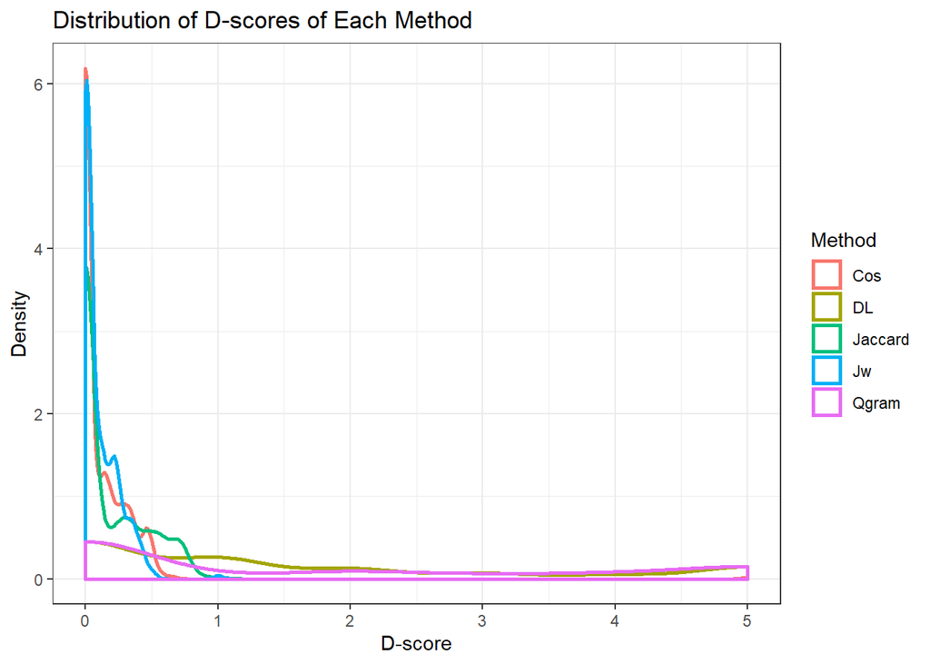

```r
ggplot(dscore_accuracy, aes(x = dscore, color = method)) +
  geom_density(size = 1) +
  scale_color_discrete(name = "Method", labels = c("Cos", "DL", "Jaccard", "Jw", "Qgram")) +
  labs(title = "Distribution of D-scores of Each Method", x = "D-score", y = "Density") +
  theme_bw()
```

# 5. Further tuning of dscore

Using dscore relative to each ED as the `max_dist` for `stringdist_join()`.

First, get the mean and sd dscore for each ED.

```r
# create summary statistics
summ_dscores <- match_dict %>%
  replace(is.na(.), 5) %>%
  group_by(ED) %>%
  summarize(mean_dl = mean(dscore_dl), sd_dl = sd(dscore_dl),
            mean_qgram = mean(dscore_qgram), sd_qgram = sd(dscore_qgram),
            mean_cos = mean(dscore_cos), sd_cos = sd(dscore_cos),
            mean_jac = mean(dscore_jac), sd_jac = sd(dscore_jac),
            mean_jw = mean(dscore_jw), sd_jw = sd(dscore_jw)) %>%
  replace(is.na(.), 0)

# format into a list such that e.g. `summ_dscores_list$0010$jw$mean` gives mean jw dscore of ED 0010
summ_dscores_list <- unique(summ_dscores$ED) %>% as.list()
names(summ_dscores_list) <- unique(summ_dscores$ED)

for (i in names(summ_dscores_list)) {
  s <- filter(summ_dscores, ED == i)
  ED_sum_list <- list(dl = list(mean = s$mean_dl, sd = s$sd_dl),
                      qgram = list(mean = s$mean_qgram, sd = s$sd_qgram),
                      cosine = list(mean = s$mean_cos, sd = s$sd_cos),
                      jaccard = list(mean = s$mean_jac, sd = s$sd_jac),
                      jw = list(mean = s$mean_jw, sd = s$sd_jw))
  summ_dscores_list[[i]] <- ED_sum_list
}
```

Run again, this time max_dist is dependent on mean and sd dscore of ED, output is `match_dict_imp`.

```r
for (i in unique(add_matches$ED)) {
  # create subset of edict and add_matches for a particular ED
  # TO ACCEPT BK: ED_dict <- filter(edict, ED == i & MNBK == "BK") %>%
  ED_dict <- filter(edict, ED == i) %>%
    select(- "ED") %>%
    unlist()
  ED_dict <- data.frame(clean = ED_dict, stringsAsFactors = FALSE) %>%
    filter(!is.na(clean))
  ED_add <- filter(add_matches, ED == i)

  for (j in str_algo) {
    # set a max_dist that varies by ED. max_dist is 2sd higher than mean.
    threshold <- summ_dscores_list[[i]][[j]]$mean + 2 * summ_dscores_list[[i]][[j]]$sd

    # stringdist_join, extract best match for each method
    result <- stringdist_left_join(ED_add, ED_dict, by = "clean",
                                   max_dist = threshold, method = j, distance_col = "dscore") %>%
    select(ED, raw, clean.x, clean.y, dscore) %>%
    group_by(raw) %>%
    arrange(dscore) %>%
    slice(1)

    # at this point, result = dataframe of addresses in ED (i), merged with method (j)
    # append result to algo_list, each element in algo_list is a dataframe
    algo_list[[j]] <- result

    # "column bind" all elements in algo_list to form a df called ed_df
    # ed_df now contains all addresses in ED(i) with matches using all methods
    ed_df <- algo_list %>%
      reduce(left_join, by = c("ED", "raw", "clean.x"))
  }
  # append each ed_df to ed_list
  ed_list[[i]] <- ed_df
}

# bind all dfs by row
match_dict_imp <- bind_rows(ed_list) %>%
    select(ED = "ED", raw = "raw", clean = "clean.x",
           match_dl = "clean.y.x", dscore_dl = "dscore.x",
           match_qgram = "clean.y.y", dscore_qgram = "dscore.y",
           match_cos = "clean.y.x.x", dscore_cos = "dscore.x.x",
           match_jac = "clean.y.y.y", dscore_jac = "dscore.y.y",
           match_jw = "clean.y", dscore_jw = "dscore")
```

## 5.1 EDA of results

How consistent are the matches?

| No. of Perfect Matches | No. of Records | % |
| --- | --- | --- |
| 0 | 359 | 58.8 |
| 2 | 10 | 1.6 |
| 5 | 242 | 39.6 |

| No. of Unique Matches Given by Algorithms | No. of Records | % |
| --- | --- | --- |
| 1 | 394 | 64.5 |
| 2 | 179 | 29.3 |
| 3 | 30 | 4.9 |
| 4 | 8 | 1.3 |

The results are similar to before. This is because the original string distance join used a very high threshold (5), hence false negatives are unlikely to occur and the results will still hold.

### Result 2: Identical matches, different from cleaned string

Exploring cases where all string algorithms returned the same result different to cleaned string:

| ED | raw | clean | match_dl | dscore_dl | match_qgram | dscore_qgram | match_cos | dscore_cos | match_jac | dscore_jac | match_jw | dscore_jw |
| --- | --- | --- | --- | --- | --- | --- | --- | --- | --- | --- | --- | --- |
| 0020 | CARL STREET | CARL | PEARL | 2 | PEARL | 3 | PEARL | 0.3291796 | PEARL | 0.5000000 | PEARL | 0.2166667 |
| 0020 | HARDISON STREET | HARDISON | MADISON | 2 | MADISON | 3 | MADISON | 0.1982163 | MADISON | 0.3333333 | MADISON | 0.1309524 |
| 0020 | PARK ROSE | PARK ROSE | PARK ROW | 2 | PARK ROW | 3 | PARK ROW | 0.1418837 | PARK ROW | 0.3333333 | PARK ROW | 0.1157407 |
| 0020 | ROOSEVLT STREET | ROOSEVLT | ROOSEVELT | 1 | ROOSEVELT | 1 | ROOSEVELT | 0.0352362 | ROOSEVELT | 0.0000000 | ROOSEVELT | 0.0370370 |
| 0021 | NAMES STREET | NAMES | JAMES | 1 | JAMES | 2 | JAMES | 0.2000000 | JAMES | 0.3333333 | JAMES | 0.1333333 |
| 0021 | SAMES STREET | SAMES | JAMES | 1 | JAMES | 2 | JAMES | 0.1548457 | JAMES | 0.2000000 | JAMES | 0.1333333 |
| 0023 | KATHERINE SREET | KATHERINE | CATHERINE | 1 | CATHERINE | 2 | CATHERINE | 0.0909091 | CATHERINE | 0.2222222 | CATHERINE | 0.0740741 |
| 0023 | KATHERINE STREET | KATHERINE | CATHERINE | 1 | CATHERINE | 2 | CATHERINE | 0.0909091 | CATHERINE | 0.2222222 | CATHERINE | 0.0740741 |
| 0023 | LIVES STREET | LIVES | OLIVER | 2 | OLIVER | 3 | OLIVER | 0.2697033 | OLIVER | 0.4285714 | OLIVER | 0.1777778 |
| 0023 | MADRIN ST | MADRIN | MADISON | 3 | MADISON | 3 | MADISON | 0.2284833 | MADISON | 0.3750000 | MADISON | 0.1507937 |
| 0023 | OLIVES STREET | OLIVES | OLIVER | 1 | OLIVER | 2 | OLIVER | 0.1666667 | OLIVER | 0.2857143 | OLIVER | 0.1111111 |
| 0024 | JAUNE SHEER | JAUNE | JAMES | 3 | JAMES | 4 | JAMES | 0.4000000 | JAMES | 0.5714286 | JAMES | 0.2666667 |
| 0024 | JAUNE STREET | JAUNE | JAMES | 3 | JAMES | 4 | JAMES | 0.4000000 | JAMES | 0.5714286 | JAMES | 0.2666667 |
| 0024 | MADDISON ST | MADDISON | MADISON | 1 | MADISON | 1 | MADISON | 0.0438171 | MADISON | 0.0000000 | MADISON | 0.0416667 |
| 0024 | OLWER | OLWER | OLIVER | 2 | OLIVER | 3 | OLIVER | 0.2697033 | OLIVER | 0.4285714 | OLIVER | 0.1777778 |
| 0024 | OLWER ST | OLWER | OLIVER | 2 | OLIVER | 3 | OLIVER | 0.2697033 | OLIVER | 0.4285714 | OLIVER | 0.1777778 |
| 0024 | OLWER STREET | OLWER | OLIVER | 2 | OLIVER | 3 | OLIVER | 0.2697033 | OLIVER | 0.4285714 | OLIVER | 0.1777778 |
| 0025 | ROSSEVELT STREET | ROSSEVELT | ROOSEVELT | 1 | ROOSEVELT | 2 | ROOSEVELT | 0.0769231 | ROOSEVELT | 0.0000000 | ROOSEVELT | 0.0740741 |
| 0026 | CATHARINE ST | CATHARINE | CATHERINE | 1 | CATHERINE | 2 | CATHERINE | 0.0909091 | CATHERINE | 0.0000000 | CATHERINE | 0.0740741 |
| 0026 | CATHARINE STREET | CATHARINE | CATHERINE | 1 | CATHERINE | 2 | CATHERINE | 0.0909091 | CATHERINE | 0.0000000 | CATHERINE | 0.0740741 |
| 0026 | DAK STREET | DAK | OAK | 1 | OAK | 2 | OAK | 0.3333333 | OAK | 0.5000000 | OAK | 0.2222222 |
| 0029 | 8 JAMES SLIP | 8 JAMES SLIP | JAMES SLIP | 2 | JAMES SLIP | 2 | JAMES SLIP | 0.0618058 | JAMES SLIP | 0.1000000 | JAMES SLIP | 0.1555556 |
| 0029 | BATTER INC SLIP | BATTER INC SLIP | CATHERINE SLIP | 4 | CATHERINE SLIP | 5 | CATHERINE SLIP | 0.1256144 | CATHERINE SLIP | 0.1538462 | CATHERINE SLIP | 0.2057720 |
| 0029 | CATHARINE SHIP | CATHARINE SHIP | CATHERINE SLIP | 2 | CATHERINE SLIP | 4 | CATHERINE SLIP | 0.1040213 | CATHERINE SLIP | 0.0833333 | CATHERINE SLIP | 0.1507937 |
| 0037 | CITY HALL AVE | CITY HALL AVENUE | CITY HALL PLACE | 5 | CITY HALL PLACE | 7 | CITY HALL PLACE | 0.1357584 | CITY HALL PLACE | 0.3076923 | CITY HALL PLACE | 0.1500000 |
| 0037 | CITY HELL PARK | CITY HELL PARK | CITY HALL PARK | 1 | CITY HALL PARK | 2 | CITY HALL PARK | 0.0513167 | CITY HALL PARK | 0.0833333 | CITY HALL PARK | 0.0989011 |
| 0037 | PARK ROUT | PARK ROUT | PARK ROW | 2 | PARK ROW | 3 | PARK ROW | 0.1418837 | PARK ROW | 0.3333333 | PARK ROW | 0.1157407 |
| 0038 | CENTER ST | CENTER | CENTRE | 1 | CENTRE | 0 | CENTRE | 0.0000000 | CENTRE | 0.0000000 | CENTRE | 0.0555556 |
| 0038 | FRANKIN | FRANKIN | FRANKLIN | 1 | FRANKLIN | 1 | FRANKLIN | 0.0513167 | FRANKLIN | 0.1428571 | FRANKLIN | 0.0416667 |
| 0038 | FRANKIN STREET | FRANKIN | FRANKLIN | 1 | FRANKLIN | 1 | FRANKLIN | 0.0513167 | FRANKLIN | 0.1428571 | FRANKLIN | 0.0416667 |

[output cut: 109 more lines]

Similarly, the string distance algorithms seem to be giving the correct match here.

Cases where string distance algorithms return different matches are shown here:

| ED | raw | clean | match_dl | dscore_dl | match_qgram | dscore_qgram | match_cos | dscore_cos | match_jac | dscore_jac | match_jw | dscore_jw |
| --- | --- | --- | --- | --- | --- | --- | --- | --- | --- | --- | --- | --- |
| 0021 | APD 18 | APD EIGHTEENTH | 0 | 0 | 0 | 0 | SAINT JAMES PLACE | 0.3935216 | SAINT JAMES PLACE | 0.5333333 | MADISON | 0.3809524 |
| 0021 | APRIL 22 | APRIL 22 | 0 | 0 | 0 | 0 | PARK ROW | 0.5000000 | PARK ROW | 0.6000000 | PARK ROW | 0.4166667 |
| 0022 | NEW BREWERY | NEW BREWERY | 0 | 0 | NEW BOWERY | 3 | NEW BOWERY | 0.0668611 | NEW BOWERY | 0.1250000 | NEW BOWERY | 0.1309764 |
| 0022 | SAMES STREET | SAMES | JAMES | 1 | JAMES | 2 | 0 | 0.0000000 | 0 | 0.0000000 | JAMES | 0.1333333 |
| 0180 | CATHARINE STREET | CATHARINE | CATHERINE | 1 | 0 | 0 | 0 | 0.0000000 | CATHERINE | 0.0000000 | CATHERINE | 0.0740741 |
| 0180 | EAST BROADWAY | EAST BROADWAY | 0 | 0 | BROADWAY EAST | 0 | BROADWAY EAST | 0.0000000 | BROADWAY EAST | 0.0000000 | 0 | 0.0000000 |
| 0024 | AVENUE ST | AVENUE | JAMES | 5 | 0 | 0 | JAMES | 0.5256584 | JAMES | 0.7500000 | JAMES | 0.4222222 |
| 0024 | S AVENUE SHEER | SOUTH AVENUE | 0 | 0 | 0 | 0 | ROSE | 0.5000000 | MADISON | 0.6923077 | OAK | 0.3888889 |
| 0024 | ST ST |  | OAK | 3 | OAK | 3 | 0 | 0.0000000 | 0 | 0.0000000 | 0 | 0.0000000 |
| 0025 | JAINES STREET | JAINES | JAMES | 2 | JAMES | 3 | SAINT JAMES PLACE | 0.2419020 | JAMES | 0.4285714 | JAMES | 0.1777778 |
| 0025 | JANIES STREET | JANIES | JAMES | 2 | JAMES | 3 | SAINT JAMES PLACE | 0.2419020 | JAMES | 0.4285714 | JAMES | 0.1777778 |
| 0025 | MADCEM STREET | MADCEM | JAMES | 4 | JAMES | 5 | JAMES | 0.3675445 | CHAMBERS | 0.5555556 | MADISON | 0.3571429 |
| 0025 | MADISON ST REAR | MADISON ST REAR | 0 | 0 | 0 | 0 | SAINT JAMES PLACE | 0.2255969 | MADISON | 0.3636364 | MADISON | 0.1777778 |
| 0025 | MADISON STREET REAR | MADISON REAR | MADISON | 6 | MADISON | 6 | SAINT JAMES PLACE | 0.2757757 | MADISON | 0.3000000 | MADISON | 0.1538462 |
| 0025 | MODREM STREET | MODREM | ROSE | 4 | ROSE | 4 | MADISON | 0.4654775 | ROSE | 0.5000000 | ROSE | 0.3888889 |
| 0025 | N BOURG | NORTH BOURG | 0 | 0 | 0 | 0 | ROSE | 0.4836022 | NEW BOWERY | 0.5833333 | NEW BOWERY | 0.4484848 |
| 0025 | NEW CHANCHERE ST | NEW CHANCHERE | 0 | 0 | 0 | 0 | NEW BOWERY | 0.3585730 | CHAMBERS | 0.5454545 | NEW BOWERY | 0.3128205 |
| 0025 | ROMAINE ST | ROMAINE | ROSE | 4 | MADISON | 4 | MADISON | 0.2857143 | MADISON | 0.4444444 | MADISON | 0.2857143 |
| 0026 | CATHARINE STREET CATHARINE STREE | CATHARINE STREET | 0 | 0 | 0 | 0 | CATHERINE | 0.1335998 | CATHERINE | 0.2000000 | CATHERINE | 0.2309368 |
| 0026 | OLWEN STREET | OLWEN | OLIVER | 3 | OLIVER | 5 | 0 | 0.0000000 | 0 | 0.0000000 | 0 | 0.0000000 |
| 0029 | 364 WATER ST | 364 WATER | WATER | 4 | WATER | 4 | 0 | 0.0000000 | 0 | 0.0000000 | 0 | 0.0000000 |
| 0029 | AMES SLIP JAMES SLIP JAMES SLIP | AMES SLIP JAMES | 0 | 0 | JAMES SLIP | 5 | JAMES SLIP | 0.0350987 | JAMES SLIP | 0.0000000 | JAMES SLIP | 0.1666667 |
| 0037 | BANDURY | BANDURY | BROADWAY | 5 | DUANE | 4 | BROADWAY | 0.2828628 | BROADWAY | 0.4444444 | BROADWAY | 0.3095238 |
| 0037 | BRANDLEY | BRANDLEY | BROADWAY | 4 | DUANE | 5 | REPUBLICAN ALLEY | 0.2372872 | REPUBLICAN ALLEY | 0.4615385 | READE | 0.2333333 |
| 0037 | CHAMLAIN ST | CHAMLAIN | CHAMBERS | 4 | CARDINAL | 4 | CARDINAL | 0.2000000 | MAIL | 0.4285714 | CARDINAL | 0.2777778 |
| 0037 | D ST | D | ELK | 3 | DUANE | 4 | 0 | 0.0000000 | READE | 0.7500000 | DUANE | 0.2666667 |
| 0037 | ENG HALL PARK | ENG HALL PARK | CITY HALL PARK | 4 | CITY HALL PARK | 7 | CITY HALL PARK | 0.1792173 | MANHATTAN PLACE | 0.4615385 | CITY HALL PARK | 0.1721612 |
| 0037 | ST CLSE HOTEL PARK ROAD | SAINT CLSE PARK ROAD | 0 | 0 | 0 | 0 | SAINT ANDREW’SOUTH PLAZA | 0.1723591 | SAINT ANDREW’SOUTH PLAZA | 0.3684211 | CITY HALL PARK | 0.2604618 |
| 0038 | HALITE STREET | HALITE | WHITE | 3 | WHITE | 3 | CATHERINE LANE | 0.2500000 | CATHERINE LANE | 0.4000000 | WHITE | 0.1777778 |
| 0038 | LACURD ST | LACURD | LEONARD | 4 | CANAL | 5 | CORTLANDT ALLEY | 0.3468027 | LEONARD | 0.5555556 | LEONARD | 0.3571429 |

[output cut: 187 more lines]

For these cases, it seems like the modal match (i.e. most common match) is a good representative of the true match. This hypothesis is tested and a few issues are described.

```r
# extract modes
match_dict_modes <- match_dict_imp %>%
  replace(is.na(.), "0") %>%
  select(- c("dscore_dl", "dscore_qgram", "dscore_cos", "dscore_jac", "dscore_jw")) %>%
  gather("method", "match", - c("ED", "raw", "clean")) %>%
  group_by(ED, raw) %>%
  summarise(mode = modal(match))

# join to match_dict_imp
match_dict_imp <- left_join(match_dict_imp, match_dict_modes, by = c("ED", "raw"))
```

How many records have single (i.e. at least 3 algorithms giving same result), non-NA modes?

```r
match_dict_imp %>%
  filter(str_detect(mode, "^[^+]+$") & mode != 0) %>%
  nrow()
```

```
## [1] 570
```

This represents 93.4% of the sample. They are again shown here:

| ED | raw | clean | mode |
| --- | --- | --- | --- |
| 0020 | CARL STREET | CARL | PEARL |
| 0020 | HARDISON STREET | HARDISON | MADISON |
| 0020 | MADISON SST | MADISON | MADISON |
| 0020 | PARK ROSE | PARK ROSE | PARK ROW |
| 0020 | PARK ROW | PARK ROW | PARK ROW |
| 0020 | PEARL STREET | PEARL | PEARL |
| 0020 | ROOSEVELT STREET | ROOSEVELT | ROOSEVELT |
| 0020 | ROOSEVLT STREET | ROOSEVLT | ROOSEVELT |
| 0021 | 191 TO 195 PARK ROW | PARK ROW | PARK ROW |
| 0021 | APRIL 22 | APRIL 22 | PARK ROW |
| 0021 | JAMES STREET | JAMES | JAMES |
| 0021 | NAMES STREET | NAMES | JAMES |
| 0021 | NEW BOWERY | NEW BOWERY | NEW BOWERY |
| 0021 | ROOSEVELT ST | ROOSEVELT | ROOSEVELT |
| 0021 | ROOSEVELT STREET | ROOSEVELT | ROOSEVELT |
| 0021 | SAMES STREET | SAMES | JAMES |
| 0022 | JAMES STREET | JAMES | JAMES |
| 0022 | MADISON STREET | MADISON | MADISON |
| 0022 | NEW BOWERY | NEW BOWERY | NEW BOWERY |
| 0022 | NEW BREWERY | NEW BREWERY | NEW BOWERY |
| 0022 | OLIVER ST | OLIVER | OLIVER |
| 0022 | OLIVER STREET | OLIVER | OLIVER |
| 0022 | PARK ROW | PARK ROW | PARK ROW |
| 0022 | SAMES STREET | SAMES | JAMES |
| 0023 | CATHERINE STREET | CATHERINE | CATHERINE |
| 0023 | KATHERINE SREET | KATHERINE | CATHERINE |
| 0023 | KATHERINE STREET | KATHERINE | CATHERINE |
| 0023 | LIVES STREET | LIVES | OLIVER |
| 0023 | MADISON STREET | MADISON | MADISON |
| 0023 | MADRIN ST | MADRIN | MADISON |

[output cut: 540 more lines]

#### Issue 1: Situations where the less common match is identical to clean

However, it is noted from the table earlier that there are a few records (10, 1.6%) were 2 string algorithms return a perfect match. This is important to examine because if only 2 string algorithms gave a true, correct match, the modal match would not identify this. These are shown here:

| ED | raw | clean | match_dl | dscore_dl | match_qgram | dscore_qgram | match_cos | dscore_cos | match_jac | dscore_jac | match_jw | dscore_jw | yes_dl | yes_qgram | yes_cos | yes_jac | yes_jw | sum_match |
| --- | --- | --- | --- | --- | --- | --- | --- | --- | --- | --- | --- | --- | --- | --- | --- | --- | --- | --- |
| 0353 | EAST 100 STREET | EAST 100 | EAST 100 | 0 | 100 EAST | 0 | 100 EAST | 0 | 100 EAST | 0 | EAST 100 | 0 | 1 | 0 | 0 | 0 | 1 | 2 |
| 0353 | EAST 100TH ST | EAST 100 | EAST 100 | 0 | 100 EAST | 0 | 100 EAST | 0 | 100 EAST | 0 | EAST 100 | 0 | 1 | 0 | 0 | 0 | 1 | 2 |
| 0353 | EAST 100TH STREET | EAST 100 | EAST 100 | 0 | 100 EAST | 0 | 100 EAST | 0 | 100 EAST | 0 | EAST 100 | 0 | 1 | 0 | 0 | 0 | 1 | 2 |
| 0354 | EAST 98 ST | EAST 98 | EAST 98 | 0 | 98 EAST | 0 | 98 EAST | 0 | 98 EAST | 0 | EAST 98 | 0 | 1 | 0 | 0 | 0 | 1 | 2 |
| 0354 | EAST 98TH STREET | EAST 98 | EAST 98 | 0 | 98 EAST | 0 | 98 EAST | 0 | 98 EAST | 0 | EAST 98 | 0 | 1 | 0 | 0 | 0 | 1 | 2 |
| 0355 | E 98 ST | EAST 98 | EAST 98 | 0 | 98 EAST | 0 | 98 EAST | 0 | 98 EAST | 0 | EAST 98 | 0 | 1 | 0 | 0 | 0 | 1 | 2 |
| 0355 | E 98 STREET | EAST 98 | EAST 98 | 0 | 98 EAST | 0 | 98 EAST | 0 | 98 EAST | 0 | EAST 98 | 0 | 1 | 0 | 0 | 0 | 1 | 2 |
| 0355 | EAST 98 STREET | EAST 98 | EAST 98 | 0 | 98 EAST | 0 | 98 EAST | 0 | 98 EAST | 0 | EAST 98 | 0 | 1 | 0 | 0 | 0 | 1 | 2 |
| 0356 | E 98 STREET | EAST 98 | EAST 98 | 0 | 98 EAST | 0 | 98 EAST | 0 | 98 EAST | 0 | EAST 98 | 0 | 1 | 0 | 0 | 0 | 1 | 2 |
| 0356 | E 98TH STREET | EAST 98 | EAST 98 | 0 | 98 EAST | 0 | 98 EAST | 0 | 98 EAST | 0 | EAST 98 | 0 | 1 | 0 | 0 | 0 | 1 | 2 |

Interestingly, this seems to reflect an issue with the way either cleaning or the street dictionary is made. All these records reflect issues of whether the number should be placed before or after a street. Once standardized, this should no longer pose an issue.

#### Issue 2: Multiple modes

There may be situations there are multiple modes.

| ED | raw | clean | mode |
| --- | --- | --- | --- |
| 0021 | APD 18 | APD EIGHTEENTH | 0+SAINT JAMES PLACE |
| 0025 | MADISON ST REAR | MADISON ST REAR | 0+MADISON |
| 0025 | N BOURG | NORTH BOURG | 0+NEW BOWERY |
| 0025 | NEW CHANCHERE ST | NEW CHANCHERE | 0+NEW BOWERY |
| 0037 | ST CLSE HOTEL PARK ROAD | SAINT CLSE PARK ROAD | 0+SAINT ANDREW’SOUTH PLAZA |
| 0040 | HIANAKIU ST | HIANAKIU | FRANKLIN+MAIN |
| 0040 | WPS ALINE ST | WPS ALINE | FRANK HOGAN PLACE+FRANKLIN |
| 0045 | HAULL STREET | HAULL | 0+CHATHAM SQUARE |
| 0050 | MATT ST PLACE | MATT ST PLACE | 0+MOTT |
| 0051 | BARFORD STREET BARFORD ST | BARFORD STREET | 0+BAYARD |
| 0051 | MOTT ELIZEBETH | MOTT ELIZEBETH | 0+ELIZABETH |
| 0133 | COURSEY ST | COURSEY | 0+CLARKSON |
| 0133 | W H | WEST H | HOUSTON WEST+WEST HOUSTON |
| 0133 | W H DOWNING | WEST H DOWNING | 0+WEST HOUSTON |
| 0353 | EAST 99TH STREEET | EAST 99 STREEET | 99 EAST+EAST 99 |

There are 15 such rows, i.e. 2.5% of the sample.

To clean these, there are a few options:  
1. Potentially use the mode that has a lower dscore–although this is problematic as the different algorithms may have different dscore ranges, hence it is hard to compare.  
2. Leave blank and fill using fill down. This is recommended as it seems that none of the matches are truly similar.  
3. Manual Cleaning.

#### Issue 3: There are matches, but the mode is NA

```r
match_dict_imp %>%
  filter(mode == "0") %>%
  filter(!(is.na(match_dl) & is.na(match_qgram) & is.na(match_cos) &
           is.na(match_jac) & is.na(match_jw))) %>%
  select(raw, clean, match_dl, match_qgram, match_cos, match_jac, match_jw) %>%
  kable() %>% kable_styling() %>% scroll_box(height = "300px")
```

| raw | clean | match_dl | match_qgram | match_cos | match_jac | match_jw |
| --- | --- | --- | --- | --- | --- | --- |
| S AVENUE SHEER | SOUTH AVENUE | NA | NA | ROSE | MADISON | OAK |
| ST ST |  | OAK | OAK | NA | NA | NA |
| OLWEN STREET | OLWEN | OLIVER | OLIVER | NA | NA | NA |
| 364 WATER ST | 364 WATER | WATER | WATER | NA | NA | NA |
| MALLERY ST | MALLERY | MULBERRY | MULBERRY | NA | NA | NA |
| REEN | REEN | MOTT | BOWERY | NA | NA | NA |
| BARREE ST | BARREE | BARROW | NA | NA | NA | NA |
| 73 | 73 | LEROY | NA | NA | NA | NA |
| 10TH STREET EAST | TENTH EAST | 100 EAST | NA | EAST 99 | 99 EAST | NA |
| E 91 ST | EAST 91 | EAST 98 | NA | NA | NA | EAST 98 |
| EAST 91 STREET | EAST 91 | EAST 98 | NA | NA | NA | EAST 98 |
| 18TH ST | EIGHTEENTH | NA | NA | 2 AVENUE | 2 AVENUE | NA |
| NINETY-FOURTH STREET 94 (94TH ST | 94 94 (94 STREET | NA | NA | EAST 94 | 94 EAST | NA |

There are 13 such records (2.1%). Again, there are instances where the match seems correct, and others where the mode is correct. Nonetheless, fill down cleaning is recommended instead, especially due to the small size of this issue.

### Result 4: No matches at all

Lastly, using this method returns records (13 records, 2.1%) that have no matches at all. These are shown below:

| ED | raw | clean | match_dl | dscore_dl | match_qgram | dscore_qgram | match_cos | dscore_cos | match_jac | dscore_jac | match_jw | dscore_jw | mode |
| --- | --- | --- | --- | --- | --- | --- | --- | --- | --- | --- | --- | --- | --- |
| 0023 | 2ND BLANK | 2 BLANK | NA | NA | NA | NA | NA | NA | NA | NA | NA | NA | 0 |
| 0047 | FLEE ST | FLEE | NA | NA | NA | NA | NA | NA | NA | NA | NA | NA | 0 |
| 0131 | LEROY STRRET | LEROY STRRET | NA | NA | NA | NA | NA | NA | NA | NA | NA | NA | 0 |
| 0354 | EAST | EAST | NA | NA | NA | NA | NA | NA | NA | NA | NA | NA | 0 |
| 0357 | 96 ST | 96 | NA | NA | NA | NA | NA | NA | NA | NA | NA | NA | 0 |
| 0358 | 95TH ST | 95 | NA | NA | NA | NA | NA | NA | NA | NA | NA | NA | 0 |
| 0359 | 95TH ST | 95 | NA | NA | NA | NA | NA | NA | NA | NA | NA | NA | 0 |
| 0359 | 96 ST | 96 | NA | NA | NA | NA | NA | NA | NA | NA | NA | NA | 0 |
| 0359 | NINTY SIXTH | 96 | NA | NA | NA | NA | NA | NA | NA | NA | NA | NA | 0 |
| 0360 | SECOND W ST | 2 WEST | NA | NA | NA | NA | NA | NA | NA | NA | NA | NA | 0 |
| 0361 | E93 ST | E93 | NA | NA | NA | NA | NA | NA | NA | NA | NA | NA | 0 |
| 0364 | 92ND ST | 92 | NA | NA | NA | NA | NA | NA | NA | NA | NA | NA | 0 |
| 0366 | WEST 90TH STREET | WEST 90 | NA | NA | NA | NA | NA | NA | NA | NA | NA | NA | 0 |

This set of records show the main usefulnessness of using a ED-based `max_dist`: nonsensical records, such as “2ND BLANK”, will not be given a false positive and can be quickly identified. These records might need to be filled down using neighboring matched records or manually cleaned.